# thermal_expansion_update

## Calculation of thermal expansion

### Update of 03/09/2021

New functions and new ways to compute thermal expansion as a function of temperature are implemented in the current release of the program; in addition, new classes are implemented to set several parameters controlling the numerical evaluation of derivatives with respect to the volume and temperature. In particular, have a check to the documentation of the classes

- volume_ctrl
- volume_F_ctrl
- delta_ctrl

on the [index](https://qm-thermodynamics.readthedocs.io/en/main/genindex.html) section of the site.

This page illustrates the new features working on the data for pyrope.

Let's load and run the program in the usual way:

```python
%matplotlib inline
%run bm3_thermal_2
```

```
This is BMx-QM program, version 2.4.3 - 03/09/2021
Run time:  2021-09-03 22:35:16.876999

File quick_start.txt found in the master folder
Input files in 'pyrope' folder

Input file

STATIC
static_new.dat
VOLUME
volume_agosto_2021.dat
FREQ
freq_agosto_2021.dat
EXP
experimental.txt
LO
LO.txt
FITVOL
SPLINE
725. 773. 16 2. 2.
FU
4 20
SET
0 1 2 3 4 5 6
CP
0.  2. -2. 1. -1. -0.5
ALPHA
0. -2  -1 -0.5
KIEFFER
73 73 130
END

-------- End of input file -------

Frequencies corrected for LO-TO splitting

Static BM3 EoS

Bulk Modulus: 173.89 (0.07) GPa
Kp:             4.26 (0.02)
V0:           756.2048 (0.00) A^3
E0:            -1.14182291e+04 (1.89e-06) hartree


Kieffer model for the acoustic branches activated
```

In order to compute thermal expansion, four methods can be used. Two of them compute the cell volume (*V*) in a specified range of temperature (*T*); the logarithm of the *V*'s are then computed and the *log(V)/T* values are fitted by using a polynomial function or a spline. The last step is to compute the first derivative of the fit to get the thermal expansion $\alpha$ from its definition:

$$\alpha(T) = \frac{d \log(V)}{d T} = \frac{1}{V} \frac{d V}{d T}$$

The two methods following this strategy differ by the functions used to get the cell volume at each temperature: one method uses the *volume_dir* function; the second one uses the *volume_from_F* function:

1. the *volume_dir* function in more general in that it can compute the equilibrium volume at any temperature and any pressure, but it requires the calculation of the pressure as the derivative of the Helmholtz function with respect to *V*; the computed volume is the one at which the total pressure of the crystal equals the imposed external pressure;
2. the second method uses the *volume_from_F* function and computes the volume as the one that minimizes the Helmholtz free energy at the given temperature (and pressure zero); this is equivalent to the minimization of the Gibbs free energy, as the pressure is zero.

Of the other two methods,

1. one uses the *alpha_dir* function that computes the volume in a small range of temperatures around the specified temperature, and subsequently makes a numerical derivative of the *V(T)* values (fitted by a given polynomials); whereas the other method
2. computes the thermal expansion from the $K\alpha$ product, where $K$ (the bulk modulus) is from an EoS fit at the specified temperature, and
   $$K\alpha = \left(\frac{\partial P}{\partial T}\right)_V$$
   is computed from the numerical derivative of a polynomial representation of the *P(T)* function (the pressures at different temperatures are computed by using the corresponding EoS)

The method (4) heavily relies on the quality of the equation of state, whereas method (3) is EoS-free as the pressures needed for the calculation are directly computed as first derivatives of the Helmholtz function, through the *pressure_dir* function (note however that the static pressure contribution is always from a static EoS).

Appropriate values of the parameters controlling the quality of fits and derivates involved can be set by the *control driver* function (check the documentation provided); the default parameters should be suitable in the majority of cases (so, no commands must be issued), but in some other cases (the presence of soft-modes producing large thermal expansions, for instance) it might be useful to get acquainted with the *volume_ctrl*, *volume_F_ctrl* and *delta_ctrl* drivers:

```python
volume_ctrl.set_all(upgrade_shift=True)
delta_ctrl.adaptive_on()
delta_ctrl.adaptive_set(dmax=50)
```

Global information of (nearly) all of the parameters and settings involved in this particular case can be retrieved by the usual *info.show* command:

```python
info.show()
```

```
Current settings and results

Static data            ** min, max volumes: 718.3435, 771.2740; points: 10
Frequency volume range ** min, max volumes: 725.7483, 772.6196; points: 7
Selected freq. sets    ** min, max volumes: 725.7483, 772.6196; points: 7
Frequency sets:           [0, 1, 2, 3, 4, 5, 6]

Fit of frequencies     ** type: spline, degree: 2, smooth: 2.0
                          min, max volumes: 725.0000, 773.0000; points 16

*** Static EoS (BM3) ***
K0: 173.89 GPa, Kp: 4.26, V0: 756.2048 A^3

No zone center excluded modes
No off center excluded modes

Kieffer model on; frequencies 73.00 73.00 130.00 cm^-1

Frequencies corrected for LO-TO splitting.


**** Volume driver for volume_dir function ****
Delta: 2.0; degree:  2; left: 2.0; right: 2.0, Kp_fix: True; t_max: 500.00
EoS shift: 0.0; Quad_shrink:  4; T_dump: 0.0; Dump fact.: 1.0, T_last  0.0
Upgrade shift: True

**** Volume driver for volume_from_F function ****
In addition to the attributes set in the parent volume_control_class:
shift: 0.0, flag: False, upgrade_shift: False

**** Numerical T-derivatives driver class (delta_ctrl) ****
Adaptive scheme active:
T_min, T_max:         50.0,  1000.0 K
Delta_min, Delta_max: 10.0,    50.0 K
Degree:        4
N. of points   8
```

Let's compute the thermal expansion of pyrope in the [100, 400 K] *T*-range (12 points) by using all of the four methods illustrated above. The command is *alpha_dir_v*; the optional parameter *comp* is set to True (the default is False) to get the computation done with all the methods available; note that if *comp* is set to False, only the method (1), described above, is used.

```
Summary of the input parameters

T range: 100.0,  400.0 K,   Num. of points:   12
Type of Log(V) fit: spline,  degree:  4,  smooth: 0.0010
Compare with other methods to compute alpha: True
Fit alpha values to a power serie: False

It is advised to use polynomial fits for 'dir' calculations

Fit of frequencies is active
Spline fit: degree  2, smooth: 2.0
Volume range: 725.00 - 773.00, points=16
```

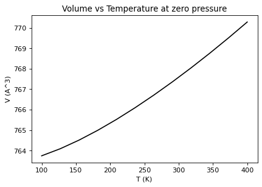

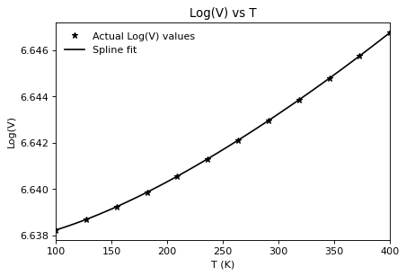

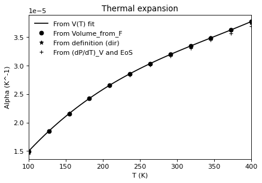

```
  Temp        V         (1)        (2)        (3)        (4)
 100.0    763.7409   1.50e-05   1.50e-05   1.47e-05   1.48e-05
 127.3    764.0887   1.85e-05   1.85e-05   1.85e-05   1.85e-05
 154.5    764.5081   2.16e-05   2.16e-05   2.16e-05   2.16e-05
 181.8    764.9875   2.42e-05   2.42e-05   2.43e-05   2.42e-05
 209.1    765.5181   2.65e-05   2.65e-05   2.65e-05   2.65e-05
 236.4    766.0935   2.86e-05   2.86e-05   2.85e-05   2.84e-05
 263.6    766.7088   3.03e-05   3.03e-05   3.03e-05   3.01e-05
 290.9    767.3605   3.20e-05   3.20e-05   3.20e-05   3.17e-05
 318.2    768.0456   3.34e-05   3.34e-05   3.35e-05   3.30e-05
 345.5    768.7622   3.49e-05   3.49e-05   3.49e-05   3.45e-05
 372.7    769.5086   3.63e-05   3.63e-05   3.63e-05   3.57e-05
 400.0    770.2841   3.77e-05   3.77e-05   3.76e-05   3.69e-05

(1) from V(T) fit
(2) from V(T) from F fit
(3) from the definition ('dir' computation)
(4) From (dP/dT)_V and EoS
```

```python
alpha_dir_v(100, 400, 12, comp=True)
```

In the figure above, the continuous line corresponds to the method (1); the full circles corresponds to the method (2); star and plus markers (barely visible in the specific case, as they overlap with the circles) corresponds to methods (3) and (4) respectively.

It is possible to compute the thermal expansion in a range of temperature (by the method (1) in the example below), fit it to a power serie and associate the coefficients of the fit to a given mineral in the database. First, compute the thermal expansion and make the fit, saving the coefficients in a given array (*alpha_fit*, for instance)

```
Summary of the input parameters

T range: 100.0,  400.0 K,   Num. of points:   12
Type of Log(V) fit: spline,  degree:  4,  smooth: 0.0010
Compare with other methods to compute alpha: False
Fit alpha values to a power serie: True
Trim applied to T and alpha values for the power serie fit:   0.0
```

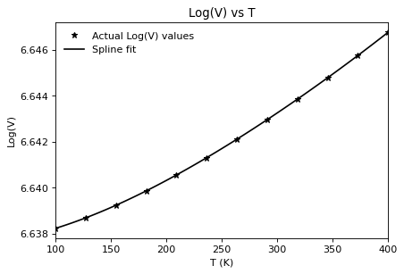

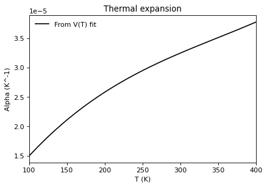

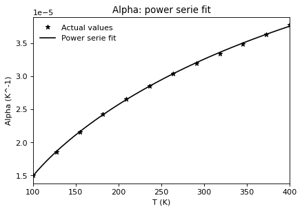

```
  Temp        V          Alpha
 100.0    763.7409    1.50e-05
 127.3    764.0887    1.85e-05
 154.5    764.5081    2.16e-05
 181.8    764.9875    2.42e-05
 209.1    765.5181    2.65e-05
 236.4    766.0935    2.86e-05
 263.6    766.7088    3.03e-05
 290.9    767.3605    3.20e-05
 318.2    768.0456    3.34e-05
 345.5    768.7622    3.49e-05
 372.7    769.5086    3.63e-05
 400.0    770.2841    3.77e-05
```

```python
alpha_fit=alpha_dir_v(100, 400, 12, comp=False, fit=True)
```

Second, load the alpha_fit coefficients in the database: for pyrope (*py* label) just issue the command:

```python
py.load_alpha(alpha_fit, power_a)
py.info()
```

```
Mineral: pyrope

K0: 173.70 GPa, Kp: 4.00, dK0/dT: -0.0261 GPa/K, V0: 11.3180 J/bar
G0: -5934105.00 J/mol, S0: 266.30 J/mol K

EoS type: bm
Cp coefficients and powers:
+6.3350e+02  +0.0
-5.1961e+06  -2.0
-4.3152e+03  -0.5

Alpha coefficients and powers:
+9.0687e-05  +0.0
-1.3196e-01  -2.0
+8.4219e-03  -1.0
-1.4677e-03  -0.5
```

Alternatively, in a single step, the phase can be specified by the optional argument *phase*:

```
Summary of the input parameters

T range: 100.0,  400.0 K,   Num. of points:   12
Type of Log(V) fit: spline,  degree:  4,  smooth: 0.0010
Compare with other methods to compute alpha: False
Fit alpha values to a power serie: True
Trim applied to T and alpha values for the power serie fit:   0.0
Power serie coefficient uploaded for the phase py
```

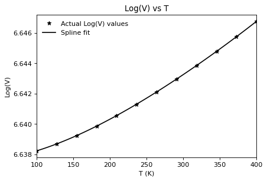

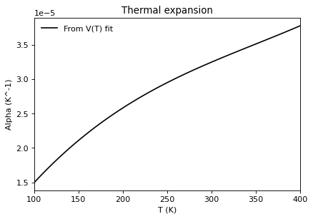

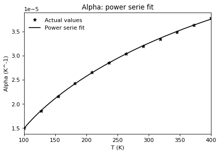

```
  Temp        V          Alpha
 100.0    763.7409    1.50e-05
 127.3    764.0887    1.85e-05
 154.5    764.5081    2.16e-05
 181.8    764.9875    2.42e-05
 209.1    765.5181    2.65e-05
 236.4    766.0935    2.86e-05
 263.6    766.7088    3.03e-05
 290.9    767.3605    3.20e-05
 318.2    768.0456    3.34e-05
 345.5    768.7622    3.49e-05
 372.7    769.5086    3.63e-05
 400.0    770.2841    3.77e-05

Mineral: pyrope

K0: 173.70 GPa, Kp: 4.00, dK0/dT: -0.0261 GPa/K, V0: 11.3180 J/bar
G0: -5934105.00 J/mol, S0: 266.30 J/mol K

EoS type: bm
Cp coefficients and powers:
+6.3350e+02  +0.0
-5.1961e+06  -2.0
-4.3152e+03  -0.5

Alpha coefficients and powers:
+9.0687e-05  +0.0
-1.3196e-01  -2.0
+8.4219e-03  -1.0
-1.4677e-03  -0.5
```

```python
alpha_dir_v(100, 400, 12, comp=False, fit=True, phase='py')
```

Other functions for getting the coefficients of the power serie of the thermal expansion are available; for instance, for method (4):

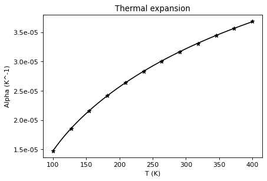

```
Mineral: pyrope

K0: 173.70 GPa, Kp: 4.00, dK0/dT: -0.0261 GPa/K, V0: 11.3180 J/bar
G0: -5934105.00 J/mol, S0: 266.30 J/mol K

EoS type: bm
Cp coefficients and powers:
+6.3350e+02  +0.0
-5.1961e+06  -2.0
-4.3152e+03  -0.5

Alpha coefficients and powers:
+8.3868e-05  +0.0
-1.0987e-01  -2.0
+6.9188e-03  -1.0
-1.2732e-03  -0.5
```

```python
alpha_fit=alpha_serie(100, 400, 12, 0, prt=False)
py.load_alpha(alpha_fit, power_a)
py.info()
```

Or the function *alpha_dir_serie* implementing the method (3):

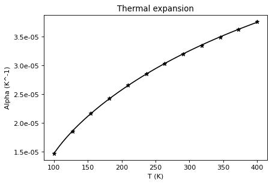

```
Temp.    Alpha
100.0   1.47e-05
127.3   1.85e-05
154.5   2.16e-05
181.8   2.43e-05
209.1   2.65e-05
236.4   2.85e-05
263.6   3.03e-05
290.9   3.20e-05
318.2   3.35e-05
345.5   3.49e-05
372.7   3.63e-05
400.0   3.76e-05

Mineral: pyrope

K0: 173.70 GPa, Kp: 4.00, dK0/dT: -0.0261 GPa/K, V0: 11.3180 J/bar
G0: -5934105.00 J/mol, S0: 266.30 J/mol K

EoS type: bm
Cp coefficients and powers:
+6.3350e+02  +0.0
-5.1961e+06  -2.0
-4.3152e+03  -0.5

Alpha coefficients and powers:
+9.1652e-05  +0.0
-1.5809e-01  -2.0
+9.0435e-03  -1.0
-1.5157e-03  -0.5
```

```python
alpha_fit=alpha_dir_serie(100, 400, 12,0)
py.load_alpha(alpha_fit, power_a)
py.info()
```

Or yet the *volume_from_F_serie* implementing the method (2):

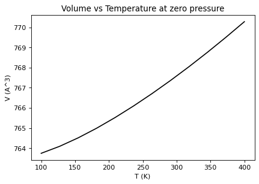

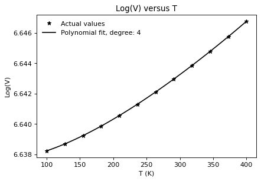

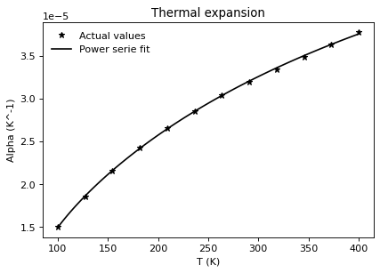

```
Mineral: pyrope

K0: 173.70 GPa, Kp: 4.00, dK0/dT: -0.0261 GPa/K, V0: 11.3180 J/bar
G0: -5934105.00 J/mol, S0: 266.30 J/mol K

EoS type: bm
Cp coefficients and powers:
+6.3350e+02  +0.0
-5.1961e+06  -2.0
-4.3152e+03  -0.5

Alpha coefficients and powers:
+9.0668e-05  +0.0
-1.3181e-01  -2.0
+8.4162e-03  -1.0
-1.4671e-03  -0.5
```

```python
alpha_fit=volume_from_F_serie(100, 400, 12, expansion=True, fit_alpha=True, export_alpha_fit=True)
py.load_alpha(alpha_fit, power_a)
py.info()
```

In summary, the four methods to compute thermal expansion are:

- **method (1)**: thermal expansion from the log(V(T)) derivative by using the *volume_dir* function; this method is implemented in the **alpha_dir_v** (with argument *comp*=False)
- **method (2)**: thermal expansion from the log(V(T)) derivative by using the *volume_from_F* function; this method is implemented in the **volume_from_F_serie** function
- **method (3)**: thermal expansion from the *local* derivative of V(T) with respect to T; this method is implemented in the **alpha_dir_serie** function
- **method (4)**: thermal expansion from $(dP/dT)_V$ and EoS; this method is implemented in the **alpha_serie** function

All of the four methods can also be applied with the single **alpha_dir_v** function by setting to True the *comp* parameter.